# Am We Locked In? - an analysis of lecture engagement

Emmanuel Araba

## What data did I collect?

I collected 40 observations on audience engagement in lectures and presentations over the course of a course of a couple months. Key metrics I recorded included the ‘fullness’ of the presentation/lecture theatre, the type of engagement I observed from the other attendees/students and also the ease of following along in the lecture

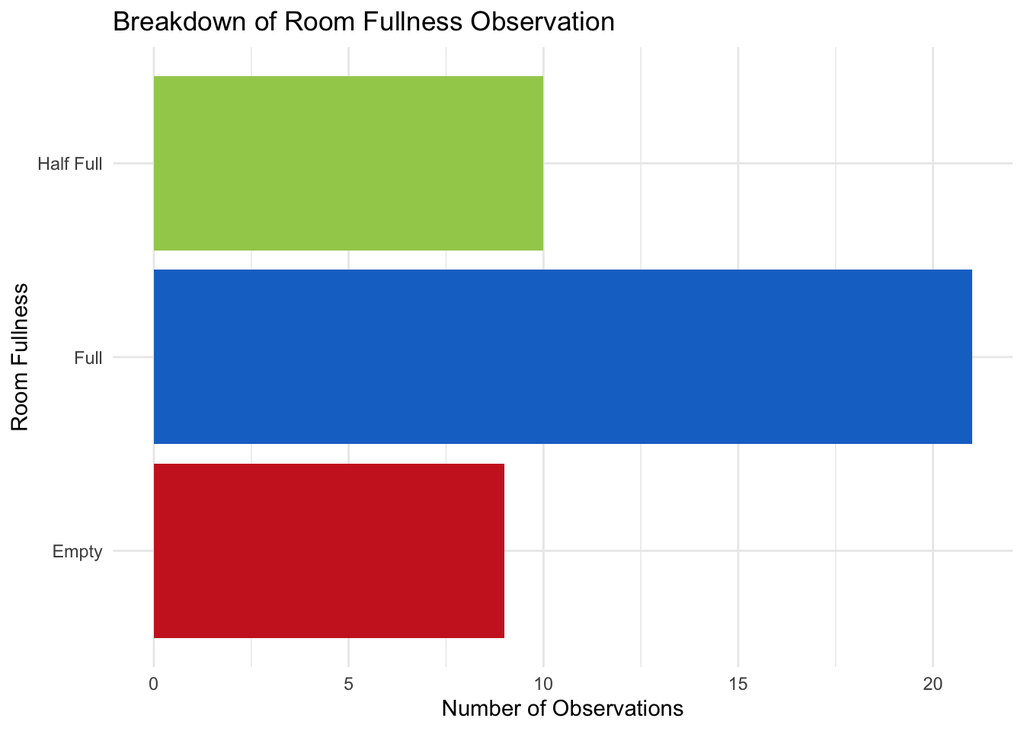

By grouping the responses into three categories: empty, half-full and full, we can see that most of the lectures/presentations I attended were full, which was surprising to me.

## Do lectures with high attendance get more engagement from the presenter?

I grouped the lectures to find out if presenters ask more questions of the audience when the room is full

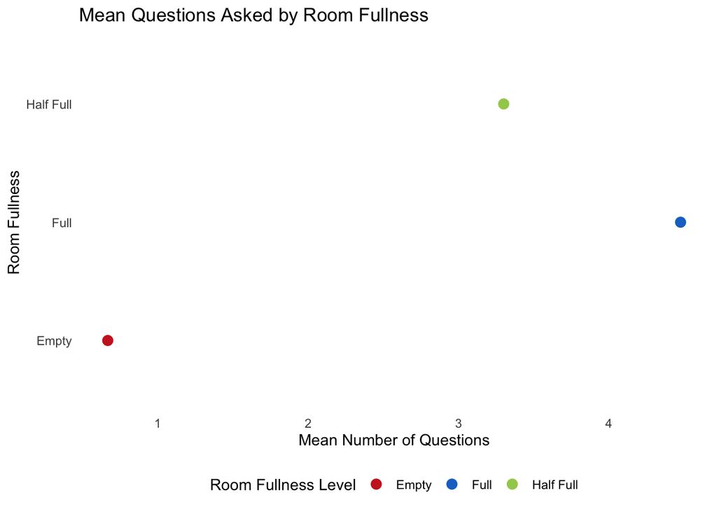

To no surprise, lecturers interact more when there are more people to interact with.

## Are students getting lecture fatigue?

Is there evidence to support the proposition that students become less engaged in lectures as time goes on? To find out, I assigned numbers to each of the responses in the survey; a score of 1 is considered low, 2 considered medium and 3 considered high, in order to quantify the amount of engagement from the audience. On days where there were multiple responses, I took the average engagement of all the observations.

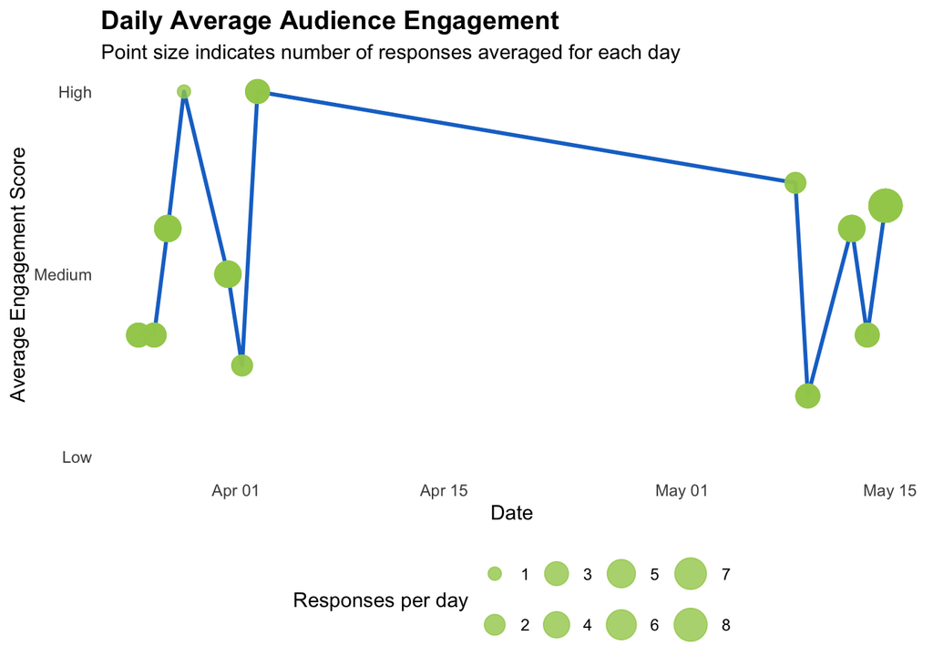

I couldn’t decipher any discernible trend from the trend in the average audience engagement over time.

## In Conclusion

In conclusion, I learnt that I get out what I put in, and lecturers/presenters are more likely to engage with me and the rest of my class if we are present, so to maximise the amount I am getting from student experience, I should show up to class!